# Examen final de Introducción a R - Versión B

Bioinformática I — Versión B

Autor/a

Azul Robles

## Instrucciones generales

**Duración: 120 minutos. Valor total: 100 puntos.**

El objetivo es reproducir dos figuras a partir de datos reales de mieles de abejas sin aguijón. Los conteos proporcionados corresponden únicamente a bacterias con asignación taxonómica a nivel de filo. Se incluyen 17 muestras de dos especies de abejas.

Trabaja en tu proyecto de RStudio y utiliza este documento como [plantilla](https://github.com/CursosENESJuriquilla/Intro_to_R_Bioinfo_2027-1/raw/refs/heads/main/versionB.qmd) Sustituye el nombre del autor por el tuyo. Agrega tus bloques de código R ejecutables y tus respuestas en las secciones correspondientes. Conserva las rutas relativas y muestra el procedimiento completo. Las figuras de referencia son una guía: no es necesario reproducir exactamente la tipografía ni los tamaños.

## Importación y exploración (10 puntos)

Descarga y descomprime datos_B.zip. Importa con `readr` los archivos `datos/conteos_filo_miel_bacterias.tsv` y `datos/metadata_miel_examen.csv`.

**Código**

```r
# Importando
conteos <- readr::read_tsv("data_raw/datos_B/conteos_filo_miel_bacterias.tsv",show_col_types =FALSE)

metadata <- readr::read_csv("data_raw/datos_B/metadata_miel_examen.csv",show_col_types =FALSE)

# dimensiones
dim(conteos)
```

```
[1] 867   3
```

**Código**

```r
dim(metadata)
```

```
[1] 17 14
```

**Código**

```r
# identificar valores faltantes
anyNA(metadata)
```

```
[1] TRUE
```

**Código**

```r
colSums(is.na(metadata))
```

```
           sample_id              species                State
                   0                    0                    0
                City               Region Zootechnic_mangement
                   0                    0                    0
      Flowering_type             Moisture                  HMF
                   0                    0                    0
               Color                   pH         Conductivity
                   0                    0                    0
                 Ash          Total_sugar
                   0                    2
```

- Indica las dimensiones de ambas tablas y el número de muestras por especie de abeja.
- Identifica si existen valores faltantes en los metadatos e indica en qué variable o variables.

## Integración y abundancia relativa (20 puntos)

Integra las dos tablas mediante el identificador `sample_id`. Calcula la abundancia relativa de cada filo dentro de cada muestra, dividiendo su conteo entre la suma de los conteos de esa muestra. Conserva las abundancias como proporciones entre 0 y 1.

**Código**

```r
# libreria
library(dplyr)
library(readr)
head(metadata)
```

```
# A tibble: 6 × 14
  sample_id species       State City  Region Zootechnic_mangement Flowering_type
  <chr>     <chr>         <chr> <chr> <chr>  <chr>                <chr>
1 Melli_21  Melipona bee… QR    Jose… Sures… Mixed honey          Multifloral
2 Melli_22  Melipona bee… QR    Jose… Sures… Jobon                Multifloral
3 Melli_39  Melipona bee… QR    Jose… Sures… Beehive box          Multifloral
4 Melli_40  Melipona bee… QR    Jose… Sures… Beehive box          Multifloral
5 Melli_41  Melipona bee… QR    Jose… Sures… Mixed honey          Multifloral
6 Melli_42  Melipona bee… QR    Jose… Sures… Jobon                Multifloral
# ℹ 7 more variables: Moisture <dbl>, HMF <dbl>, Color <chr>, pH <dbl>,
#   Conductivity <dbl>, Ash <dbl>, Total_sugar <dbl>
```

**Código**

```r
# integrar
# checamos que sí correspondan
metadata %>%
  count(sample_id) %>%
  arrange(desc(n))
```

```
# A tibble: 17 × 2
   sample_id     n
   <chr>     <int>
 1 Melli_21      1
 2 Melli_22      1
 3 Melli_39      1
 4 Melli_40      1
 5 Melli_41      1
 6 Melli_42      1
 7 Melli_45      1
 8 Melli_46      1
 9 Melli_47      1
10 Scapto_23     1
11 Scapto_43     1
12 Scapto_51     1
13 Scapto_89     1
14 Scapto_90     1
15 Scapto_91     1
16 Scapto_92     1
17 Scapto_93     1
```

**Código**

```r
conteos %>%
  count(sample_id) %>%
  arrange(desc(n))
```

```
# A tibble: 17 × 2
   sample_id     n
   <chr>     <int>
 1 Melli_21     51
 2 Melli_22     51
 3 Melli_39     51
 4 Melli_40     51
 5 Melli_41     51
 6 Melli_42     51
 7 Melli_45     51
 8 Melli_46     51
 9 Melli_47     51
10 Scapto_23    51
11 Scapto_43    51
12 Scapto_51    51
13 Scapto_89    51
14 Scapto_90    51
15 Scapto_91    51
16 Scapto_92    51
17 Scapto_93    51
```

**Código**

```r
# ahora si integramos
integrado <- conteos %>%
  left_join(metadata, by = "sample_id")
head(integrado)
```

```
# A tibble: 6 × 16
  sample_id filo          conteo species State City  Region Zootechnic_mangement
  <chr>     <chr>          <dbl> <chr>   <chr> <chr> <chr>  <chr>
1 Melli_21  Acidobacteri… 2.18e3 Melipo… QR    Jose… Sures… Mixed honey
2 Melli_21  Actinomyceto… 7.46e4 Melipo… QR    Jose… Sures… Mixed honey
3 Melli_21  Aquificota    3.24e2 Melipo… QR    Jose… Sures… Mixed honey
4 Melli_21  Armatimonado… 2.38e2 Melipo… QR    Jose… Sures… Mixed honey
5 Melli_21  Atribacterota 1.9 e1 Melipo… QR    Jose… Sures… Mixed honey
6 Melli_21  Bacillota     5.96e6 Melipo… QR    Jose… Sures… Mixed honey
# ℹ 8 more variables: Flowering_type <chr>, Moisture <dbl>, HMF <dbl>,
#   Color <chr>, pH <dbl>, Conductivity <dbl>, Ash <dbl>, Total_sugar <dbl>
```

**Código**

```r
# abundancia relativa
abundancias <- integrado %>%
  group_by(sample_id, filo) %>%
  summarise(conteo = sum(conteo), .groups = "drop") %>%
  group_by(sample_id) %>%
  mutate(abundancia_relativa = conteo / sum(conteo)) %>%
  ungroup()

abundancias %>%
  select(sample_id, filo, abundancia_relativa) %>%
  head()
```

```
# A tibble: 6 × 3
  sample_id filo            abundancia_relativa
  <chr>     <chr>                         <dbl>
1 Melli_21  Acidobacteriota          0.000337
2 Melli_21  Actinomycetota           0.0115
3 Melli_21  Aquificota               0.0000501
4 Melli_21  Armatimonadota           0.0000368
5 Melli_21  Atribacterota            0.00000294
6 Melli_21  Bacillota                0.921
```

## Figura 1: los 10 filos más abundantes (25 puntos)

Calcula la abundancia relativa promedio de cada filo considerando las 17 muestras, incluidos los conteos cero. Selecciona los diez con mayor promedio y reproduce la gráfica de barras horizontales ordenadas de mayor a menor. Muestra el eje de abundancia en porcentajes y agrega etiquetas apropiadas.

**Código**

```r
# abundancia relativa promedio
promedios <- abundancias %>%
  group_by(filo) %>%
  summarise(
    abundancia_promedio = mean(abundancia_relativa), .groups = "drop"
  )

promedios %>%
  select(filo, abundancia_promedio)
```

```
# A tibble: 51 × 2
   filo             abundancia_promedio
   <chr>                          <dbl>
 1 Acidobacteriota            0.000256
 2 Actinomycetota             0.00874
 3 Aquificota                 0.0000396
 4 Armatimonadota             0.0000240
 5 Atribacterota              0.0000570
 6 Bacillota                  0.851
 7 Bacteroidota               0.0169
 8 Balneolota                 0.0000374
 9 Bdellovibrionota           0.000488
10 Caldisericota              0.0000143
# ℹ 41 more rows
```

**Código**

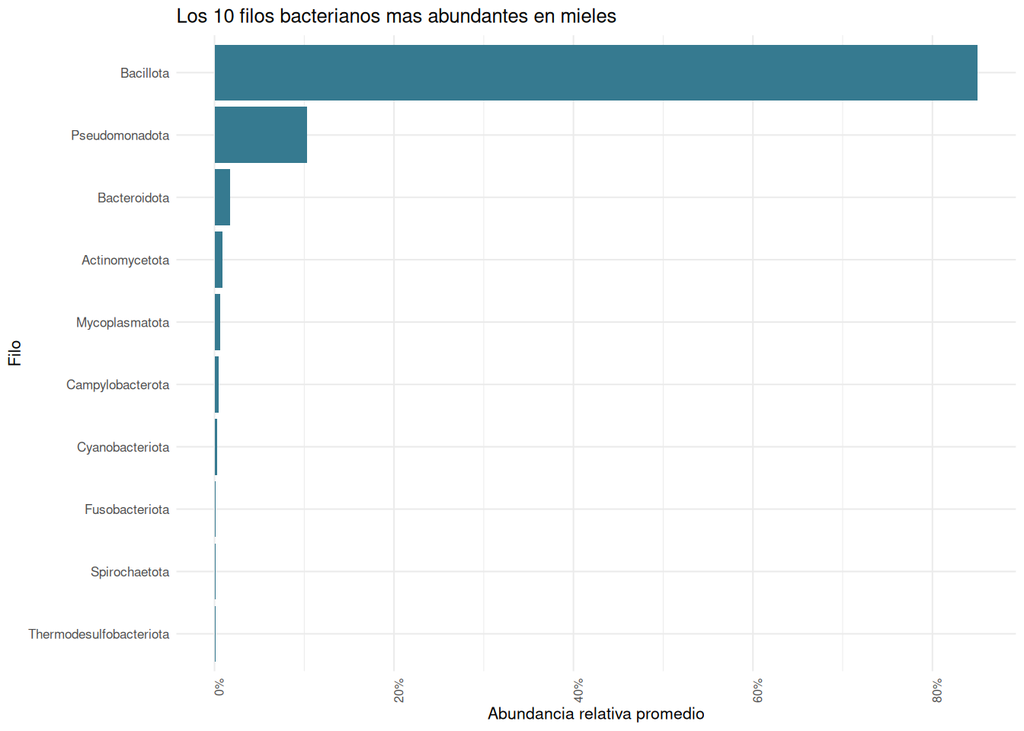

```r
# mejores 10
mejores <- promedios %>%
  slice_max(abundancia_promedio, n=10)

# grafica ordenanda de mayor a menor, mostrar eje abundancia en % y etiquetas
library(ggplot2)
fig1 <- ggplot(mejores, aes(
  x = abundancia_promedio, y = reorder(filo, abundancia_promedio))) +
  geom_col(fill = "#367A90") +
  scale_x_continuous(labels = function(x) paste0(round(100 * x), "%")) +
  labs(title = "Los 10 filos bacterianos mas abundantes en mieles", x = "Abundancia relativa promedio",
       y = "Filo") +
  theme_minimal(base_size = 8) +
  theme(axis.text.x = element_text(angle = 90, hjust = 1, size = 6))
fig1
```

## Figura 2: composición bacteriana por muestra (30 puntos)

Utiliza las abundancias relativas del apartado 2, **no solamente los diez taxones de la figura anterior**.

- Dentro de cada muestra, agrupa los filos cuya abundancia relativa sea estrictamente menor al 5 % en la categoría `Filos < 5%`. Suma las abundancias de esa categoría.
- Construye una gráfica de barras apiladas, una barra por muestra, separando las especies de abejas mediante facetas. Cada barra debe sumar 100 %.
- Utiliza la paleta proporcionada y coloca la leyenda debajo de la gráfica.

Paleta de referencia (puedes copiarla en un bloque de R) o puedes usar otra paleta de colores:

```r
phylum_colors_rel <- c(
  "Bacillota" = "#0078A0",
  "Pseudomonadota" = "#499878",
  "Filos < 5%" = "#778899"
)
```

**Código**

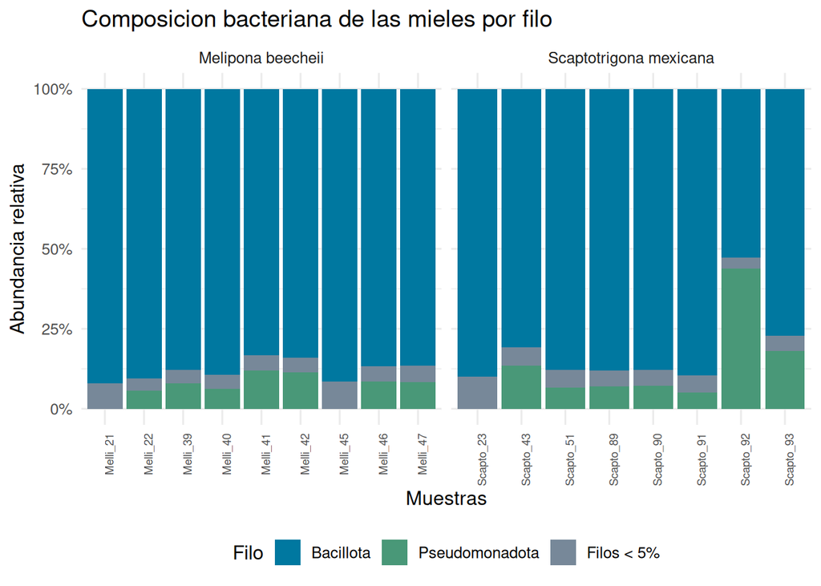

```r
# Figura 2: composición por muestra

# agregar host_name, agrupar filos < 5% y sumarlos
fig2 <- abundancias %>%
  left_join(metadata, by = "sample_id") %>%
  mutate(filo = if_else(abundancia_relativa < 0.05, "Filos < 5%", filo)) %>%
  group_by(sample_id, species, filo) %>%
  summarise(abundancia_relativa = sum(abundancia_relativa), .groups = "drop")


orden_filos <- c(
  sort(setdiff(unique(abundancias$filo), "Filos < 5%")),
  "Filos < 5%"
)

colores <- c(
  "Bacillota" = "#0078A0",
  "Pseudomonadota" = "#499878",
  "Filos < 5%" = "#778899"
)

figura2 <- ggplot(fig2,
       aes(x = sample_id, y = abundancia_relativa, fill = filo)) +
  geom_col() +
  scale_fill_manual(values = colores,
                    breaks = orden_filos) +
  facet_wrap(~ species, scales = "free_x") +
  scale_y_continuous(labels = function(x) paste0(round(100 * x), "%")) +
  labs(title = "Composicion bacteriana de las mieles por filo",
       x = "Muestras", y = "Abundancia relativa", fill = "Filo") +
  theme_minimal(base_size = 12) +
  theme(axis.text.x = element_text(angle = 90, hjust = 1, size = 7),
        legend.position = "bottom")
figura2
```

## Interpretación (5 puntos)

Responde brevemente con base en tus resultados:

**Nota**: Todas las muestras pertenecen al mismo estudio y fueron procesadas con la misma metodología.

## Reporte reproducible y entrega (10 puntos)

**Código**

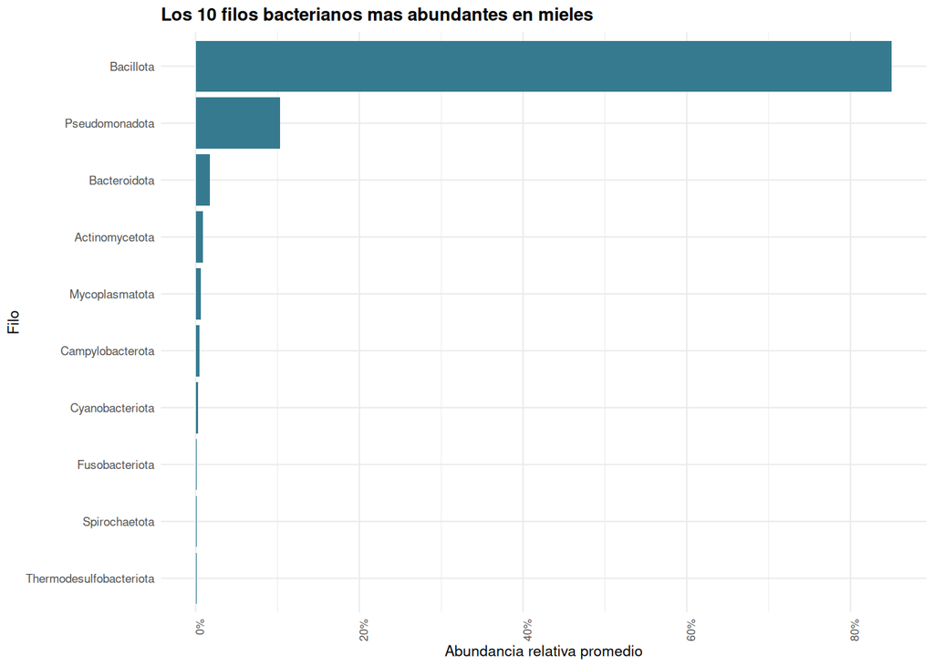

```r
# figura 1
p_publicacion <- fig1 +
  theme(
    plot.title = element_text(face = "bold"),
    strip.text = element_text(face = "bold"),
    legend.position = "bottom"
  )
p_publicacion
```

**Código**

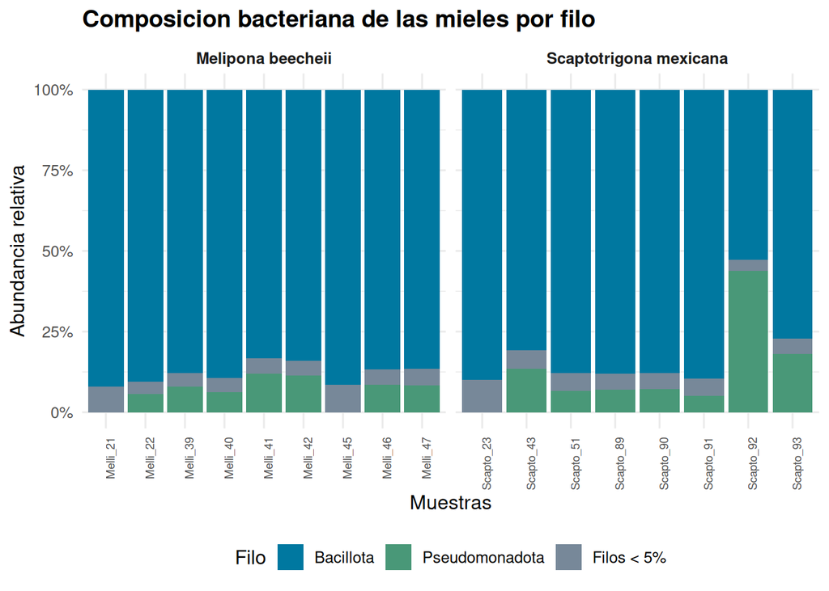

```r
dir.create("figures", showWarnings = FALSE)

ggsave("figures/figura1.png",
       plot = p_publicacion, width = 12, height = 7,
       units = "in", dpi = 300)

# figura 2
pub2 <- figura2 +
  theme(
    plot.title = element_text(face = "bold"),
    strip.text = element_text(face = "bold"),
    legend.position = "bottom"
  )
pub2
```

**Código**

```r
ggsave("figures/figura2.png",
       plot = pub2, width = 12, height = 7,
       units = "in", dpi = 300)
```

Renderiza el documento a HTML y sube a tu repositorio de GitHub el archivo `.qmd`, el HTML generado y las carpetas de datos y figuras necesarias. Verifica que el HTML muestre tus resultados y gráficas sin necesidad de ejecutar el código nuevamente. Entrega el enlace al repositorio.

Si tienes un problema técnico con GitHub, conserva el `.qmd` y el HTML y notifícalo a la profesora antes de finalizar el examen.